# Does Money Buy Wins? An Analysis of Payroll Efficiency in Major League Baseball (2021–2026)

Borna Anic-Matic

2026-10-30

As the 2026 MLB season comes to an end, with the Milwaukee Brewers crowned World Series champions for the first time in franchise history, discussions surrounding a potential lockout and the introduction of salary caps and floors have raised an important question: **To what extent does a team’s payroll predict its success?**

This project aims to investigate the relationship between team payroll and regular-season success in Major League Baseball from 2021 to 2026, examining whether payroll can serve as a reliable predictor of a team’s performance.

```r
install.packages('baseballr')
install.packages("rvest")
install.packages("readxl")
library(baseballr)
library(tidyverse)
library(dplyr)
library(readxl)
```

```r
# Create an empty list to store standings
standings_list <- list()

# Loop through each year
for (year in 2021:2026) {

  # Retrieve American League standings
  AL <- mlb_standings(
    season = year,
    league_id = 103
  )

  # Retrieve National League standings
  NL <- mlb_standings(
    season = year,
    league_id = 104
  )

  # Combine both leagues
  season_standings <- bind_rows(AL, NL)

  # Add the year as a variable
  season_standings$year <- year

  # Store the results
  standings_list[[as.character(year)]] <- season_standings
}

# Combine all seasons into one dataframe
mlb_standings_all <- bind_rows(standings_list)
```

```r
excel_sheets("MLB Salaries.xlsx")
```

```
## [1] "2021" "2022" "2023" "2024" "2025" "2026"
```

```r
payroll_data <- bind_rows(
  lapply(2021:2026, function(year) {
    read_excel(
      "MLB Salaries.xlsx",
      sheet = as.character(year)
    )
  })
)
```

```r
#View(payroll_data)

dim(payroll_data)
```

```
## [1] 180  12
```

```r
names(payroll_data)
```

```
##  [1] "year"              "team"              "roster"
##  [4] "league"            "division"          "team payroll"
##  [7] "w"                 "l"                 "rank"
## [10] "lg rk"             "mlb rk"            "last year payroll"
```

```r
mlb_payroll <- payroll_data %>%
               mutate(`difference in payroll` = `team payroll` - `last year payroll`)  %>%
               select(year, team, `team payroll`, w, l, `last year payroll`, `difference in payroll`)

mlb_payroll
```

```
## # A tibble: 180 × 7
##     year team                  `team payroll`     w     l `last year payroll`
##    <dbl> <chr>                          <dbl> <dbl> <dbl>               <dbl>
##  1  2021 Los Angeles Dodgers        241372403   106    56           189065000
##  2  2021 New York Yankees           201074956    92    70           214291339
##  3  2021 New York Mets              186001814    77    85           142288337
##  4  2021 Los Angeles Angels         180609676    77    85           176329344
##  5  2021 Washington Nationals       179557685    65    97           159242411
##  6  2021 Boston Red Sox             179540260    92    70           120361000
##  7  2021 Houston Astros             176495417    95    67           212321933
##  8  2021 San Diego Padres           175713986    79    83           140317600
##  9  2021 Philadelphia Phillies      174808832    82    80           152877962
## 10  2021 St. Louis Cardinals        164972833    90    72           160781766
## # ℹ 170 more rows
## # ℹ 1 more variable: `difference in payroll` <dbl>
```

```r
summary(mlb_payroll)
```

```
##       year          team            team payroll             w
##  Min.   :2021   Length:180         Min.   : 32548334   Min.   : 41.00
##  1st Qu.:2022   Class :character   1st Qu.:103226636   1st Qu.: 74.00
##  Median :2024   Mode  :character   Median :146817194   Median : 82.00
##  Mean   :2024                      Mean   :158835359   Mean   : 80.98
##  3rd Qu.:2025                      3rd Qu.:202224099   3rd Qu.: 90.00
##  Max.   :2026                      Max.   :415212461   Max.   :111.00
##        l          last year payroll   difference in payroll
##  Min.   : 51.00   Min.   : 32548334   Min.   :-76412871
##  1st Qu.: 72.00   1st Qu.: 94375702   1st Qu.: -9844578
##  Median : 80.00   Median :140794395   Median : 12433574
##  Mean   : 80.97   Mean   :145528870   Mean   : 13306489
##  3rd Qu.: 88.00   3rd Qu.:184619973   3rd Qu.: 34941151
##  Max.   :121.00   Max.   :334233332   Max.   :105809360
```

## Examining the Relationship Between Team Payroll and Regular-Season Performance (2021–2026)

To begin the anyalsis, we will be comparing a teams payroll for a given year versue the amount of wins and losses they obtained. To do this we will first graph the data agaisnt each other and then we will calculate correaltion tests to quantify what the graphs are showing.

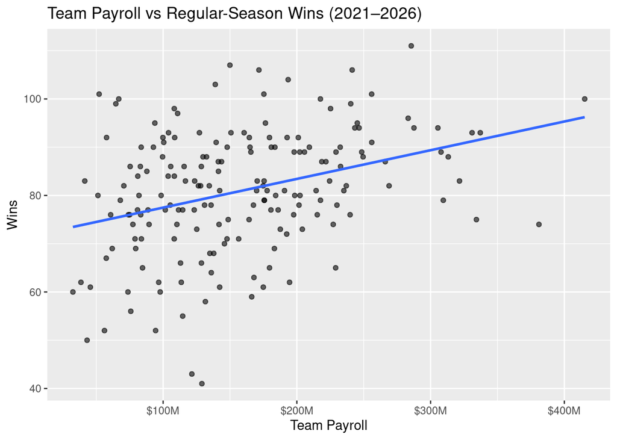

```r
# Payroll vs Wins
ggplot(mlb_payroll, aes(x = `team payroll`, y = w)) +
  geom_point(alpha = 0.6) +
  geom_smooth(method = "lm", se = FALSE) +
  scale_x_continuous(
    labels = scales::label_number(
      scale = 1e-6,
      prefix = "$",
      suffix = "M"
    )
  ) +
  labs(
    title = "Team Payroll vs Regular-Season Wins (2021–2026)",
    x = "Team Payroll",
    y = "Wins"
  )
```

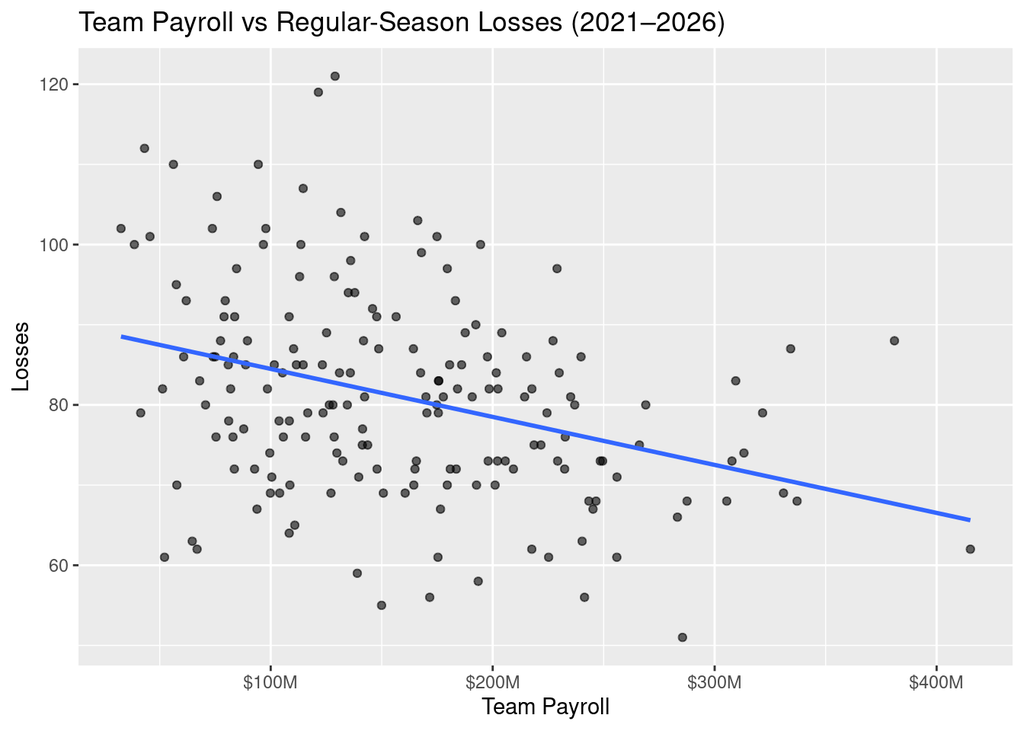

```r
# Payroll vs Losses
ggplot(mlb_payroll, aes(x = `team payroll`, y = l)) +
  geom_point(alpha = 0.6) +
  geom_smooth(method = "lm", se = FALSE) +
  scale_x_continuous(
    labels = scales::label_number(
      scale = 1e-6,
      prefix = "$",
      suffix = "M"
    )
  ) +
  labs(
    title = "Team Payroll vs Regular-Season Losses (2021–2026)",
    x = "Team Payroll",
    y = "Losses"
  )
```

```r
cor_win_payroll <- cor(mlb_payroll$w,mlb_payroll$`team payroll`)
cor_loss_payroll <- cor(mlb_payroll$l,mlb_payroll$`team payroll`)

rsqu_win_payroll <- cor(mlb_payroll$w,mlb_payroll$`team payroll`)^2
rsqu_loss_payroll <- cor(mlb_payroll$l,mlb_payroll$`team payroll`)^2

cor_win_payroll
```

```
## [1] 0.3417451
```

```r
cor_loss_payroll
```

```
## [1] -0.3430683
```

```r
rsqu_win_payroll
```

```
## [1] 0.1167897
```

```r
rsqu_loss_payroll
```

```
## [1] 0.1176959
```

The relationship between team payroll and wins appears to be positively correlated, although the strength of this relationship is relatively weak to moderate. An R-squared value of 0.1167 indicates that approximately 11.67% of the variation in a team’s wins can be explained by its payroll.

Conversely, the relationship between team payroll and losses is negative, with a similarly weak to moderate correlation. An R-squared value of 0.1177 indicates that approximately 11.77% of the variation in a team’s losses can be explained by its payroll.

Overall, these findings suggest that team payroll alone is a relatively weak predictor of regular-season performance. While higher payrolls are generally associated with more wins and fewer losses, a substantial proportion of the variation in team performance remains unexplained by payroll alone.

## Examining the Relationship Between Year-Over-Year Changes in Team Payroll and Regular-Season Performance (2021–2026)

```r
payroll_data_2 <- payroll_data %>% group_by(team) %>%
                  arrange(year, .by_group = TRUE) %>%
                  mutate(wins_change = w - lag(w)) %>%
                  ungroup()

payroll_data_2 <- payroll_data_2 %>% group_by(team) %>%
                  arrange(year, .by_group = TRUE) %>%
                  mutate(losses_change = l - lag(l)) %>%
                  ungroup()

payroll_data_2 <- payroll_data_2 %>% group_by(team) %>%
                  arrange(year, .by_group = TRUE) %>%
                  mutate(payroll_change = `team payroll` - lag(`team payroll`)) %>%
                  ungroup()
```

```r
payroll_data_2 <- payroll_data_2 %>%
  tidyr::drop_na(wins_change, losses_change, payroll_change)
```

```r
avg_win_change <-mean(payroll_data_2$wins_change)
avg_win_change
```

```
## [1] -0.1283784
```

```r
avg_loss_change <- mean(payroll_data_2$losses_change)
avg_loss_change
```

```
## [1] 0.1283784
```

```r
avg_payroll_change <- mean(payroll_data_2$payroll_change)
avg_payroll_change
```

```
## [1] 15454375
```

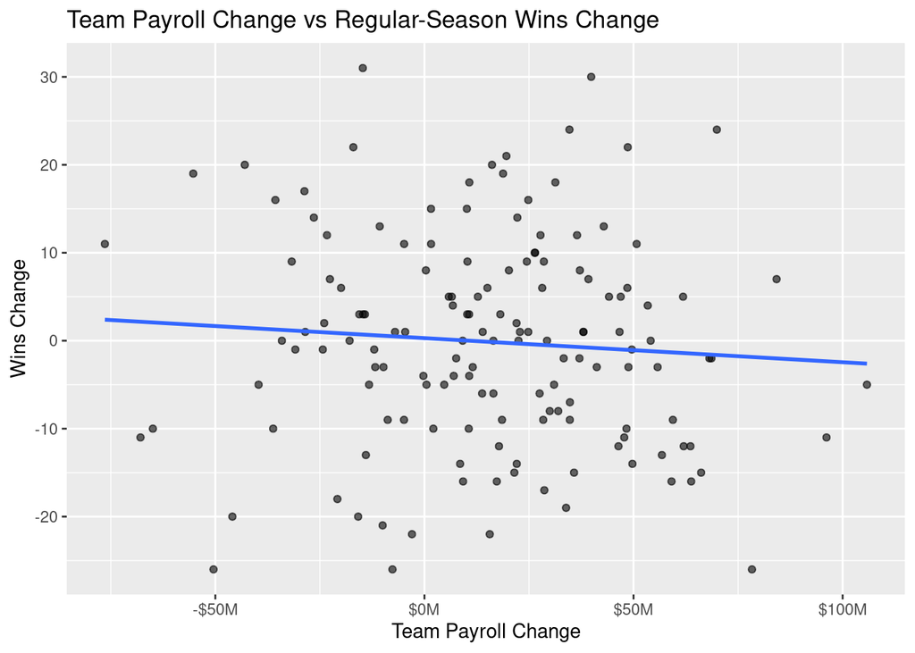

```r
# Change in Payroll vs Change in Wins
ggplot(payroll_data_2, aes(x = payroll_change, y = wins_change)) +
  geom_point(alpha = 0.6) +
  geom_smooth(method = "lm", se = FALSE) +
  scale_x_continuous(
    labels = scales::label_number(
      scale = 1e-6,
      prefix = "$",
      suffix = "M"
    )
  ) +
  labs(
    title = "Team Payroll Change vs Regular-Season Wins Change",
    x = "Team Payroll Change",
    y = "Wins Change"
  )
```

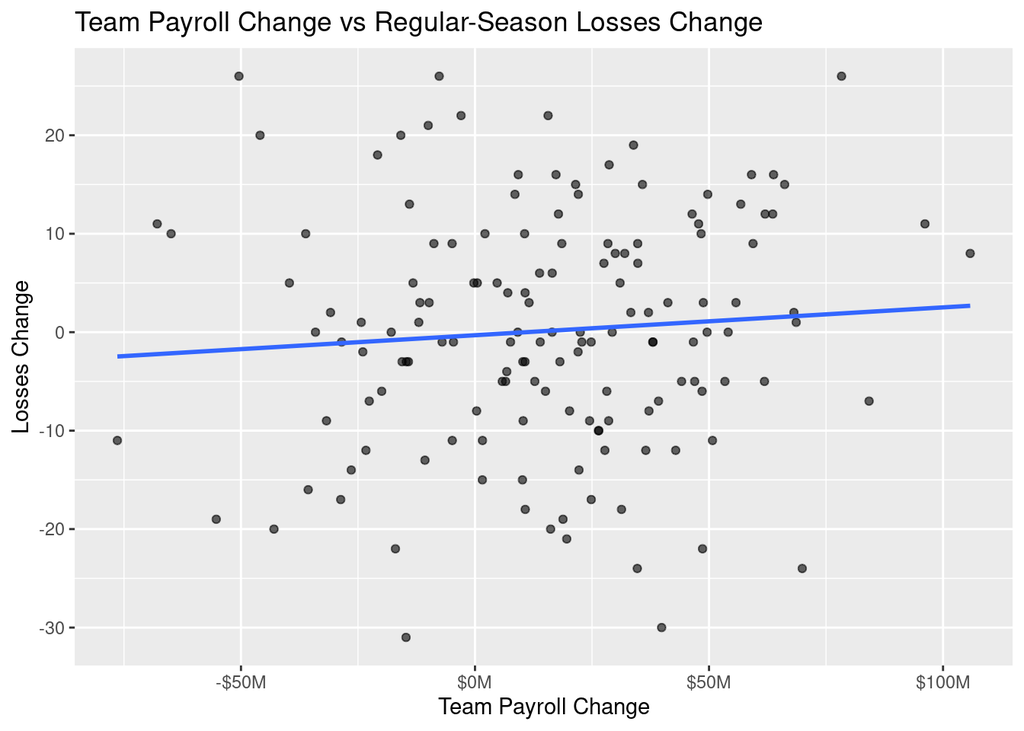

```r
ggplot(payroll_data_2, aes(x = payroll_change, y = losses_change)) +
  geom_point(alpha = 0.6) +
  geom_smooth(method = "lm", se = FALSE) +
  scale_x_continuous(
    labels = scales::label_number(
      scale = 1e-6,
      prefix = "$",
      suffix = "M"
    )
  ) +
  labs(
    title = "Team Payroll Change vs Regular-Season Losses Change",
    x = "Team Payroll Change",
    y = "Losses Change"
  )
```

```r
cor_winschange_payrollchange <- cor(payroll_data_2$wins_change, payroll_data_2$payroll_change)
cor_losseschange_payrollchange <-cor(payroll_data_2$losses_change, payroll_data_2$payroll_change)

cor_winschange_payrollchange
```

```
## [1] -0.07591715
```

```r
cor_losseschange_payrollchange
```

```
## [1] 0.07813704
```

```r
cor_winschange_payrollchange^2
```

```
## [1] 0.005763413
```

```r
cor_losseschange_payrollchange^2
```

```
## [1] 0.006105397
```

The relationship between year-over-year changes in team payroll and changes in regular-season performance appears to be extremely weak.

The correlation between changes in payroll and wins was -0.0759, indicating a very weak negative relationship. An R-squared value of 0.00576 suggests that approximately 0.58% of the variation in year-over-year changes in wins can be explained by changes in team payroll.

Conversely, the correlation between changes in payroll and losses was 0.0781, indicating a very weak positive relationship. The corresponding R-squared value of 0.00611 indicates that approximately 0.61% of the variation in changes in losses can be explained by changes in payroll.

Overall, these findings suggest that increases or decreases in team payroll have little linear association with improvements or declines in regular-season performance. While changes in spending may influence individual teams, the results indicate that payroll changes alone are not reliable predictors of year-over-year changes in wins or losses across Major League Baseball.